# Final Project

Hyojun Kim

2023-05-22

# 1. Problem Statement:

The objective of this project is to develop a robust forecasting model to predict the future returns of Bitcoin based on historical trade data. Bitcoin, the longest-running and most well-known cryptocurrency, was first released as open source in 2009 by the anonymous Satoshi Nakamoto. It operates as a decentralized medium of digital exchange, with transactions verified and recorded in a public distributed ledger called the blockchain.

The historical Bitcoin market data provided in the form of CSV files contains minute-to-minute updates of various metrics, including OHLC (Open, High, Low, Close) prices, Volume in BTC and indicated currency, and weighted Bitcoin price. The data spans from January 2012 to March 2021, covering a significant period of Bitcoin’s trading history.

With this data, we aim to develop a forecasting model that leverages the historical trade data to predict the future returns of Bitcoin. By analyzing factors such as trade volume, opening price, closing price, and other technical indicators, we can gain insights into the future price movements of Bitcoin.

# 2. Assumptions/Hypotheses about Data and/or Modeling:

Assumption: Cryptocurrency markets, including Bitcoin, are influenced by various factors such as trade volume, opening price, closing price, and other technical indicators. These factors have the potential to provide valuable information for predicting future returns.

Hypothesis: Increased trade volume in Bitcoin may indicate higher demand, potentially leading to increased returns. Extreme highs or lows in Bitcoin price within a given time period could suggest a volatile market, which might influence future returns.

Modeling Approach: To forecast Bitcoin prices, we will employ several models including ARFIMA (AutoRegressive Fractionally Integrated Moving Average), ARIMA (AutoRegressive Integrated Moving Average), ETS (Exponential Smoothing State Space Model) and SARIMA (Seasonal AutoRegressive Integrated Moving Average). These models are capable of capturing dependencies and incorporating memory into the forecasting process.

# 3. Data Preparation:

```r
# Load the data
data <- read.csv('/Users/hyojun/Desktop/data/bitstampUSD_1-min_data_2012-01-01_to_2021-03-31.csv')

# Convert Timestamp to datetime format
data$Timestamp <- as.POSIXct(data$Timestamp, origin = "1970-01-01", tz = "UTC")

# Check data structure
str(data)
```

```
## 'data.frame':    4857377 obs. of  8 variables:
##  $ Timestamp        : POSIXct, format: "2011-12-31 07:52:00" "2011-12-31 07:53:00" ...
##  $ Open             : num  4.39 NaN NaN NaN NaN NaN NaN NaN NaN NaN ...
##  $ High             : num  4.39 NaN NaN NaN NaN NaN NaN NaN NaN NaN ...
##  $ Low              : num  4.39 NaN NaN NaN NaN NaN NaN NaN NaN NaN ...
##  $ Close            : num  4.39 NaN NaN NaN NaN NaN NaN NaN NaN NaN ...
##  $ Volume_.BTC.     : num  0.456 NaN NaN NaN NaN ...
##  $ Volume_.Currency.: num  2 NaN NaN NaN NaN ...
##  $ Weighted_Price   : num  4.39 NaN NaN NaN NaN NaN NaN NaN NaN NaN ...
```

```r
# Summary statistics
summary(data)
```

```
##    Timestamp                           Open              High
##  Min.   :2011-12-31 07:52:00.00   Min.   :    3.8   Min.   :    3.8
##  1st Qu.:2014-04-22 14:56:00.00   1st Qu.:  443.9   1st Qu.:  444.0
##  Median :2016-08-17 09:52:00.00   Median : 3597.0   Median : 3598.2
##  Mean   :2016-08-15 22:39:26.50   Mean   : 6009.0   Mean   : 6013.4
##  3rd Qu.:2018-12-08 16:56:00.00   3rd Qu.: 8627.3   3rd Qu.: 8633.0
##  Max.   :2021-03-31 00:00:00.00   Max.   :61763.6   Max.   :61781.8
##                                   NA's   :1243608   NA's   :1243608
##       Low              Close          Volume_.BTC.     Volume_.Currency.
##  Min.   :    1.5   Min.   :    1.5   Min.   :   0.0    Min.   :       0
##  1st Qu.:  443.5   1st Qu.:  443.9   1st Qu.:   0.4    1st Qu.:     452
##  Median : 3595.6   Median : 3597.0   Median :   2.0    Median :    3810
##  Mean   : 6004.5   Mean   : 6009.0   Mean   :   9.3    Mean   :   41763
##  3rd Qu.: 8621.1   3rd Qu.: 8627.2   3rd Qu.:   7.3    3rd Qu.:   25698
##  Max.   :61673.6   Max.   :61781.8   Max.   :5853.9    Max.   :13900672
##  NA's   :1243608   NA's   :1243608   NA's   :1243608   NA's   :1243608
##  Weighted_Price
##  Min.   :    3.8
##  1st Qu.:  443.8
##  Median : 3596.8
##  Mean   : 6008.9
##  3rd Qu.: 8627.6
##  Max.   :61716.2
##  NA's   :1243608
```

# 4. Data Properties (Stationarity, Correlations, Data Distribution) and Exploratory Data Analysis

```r
# Check for missing values
print(paste("Missing values: ", sum(is.na(data))))
```

```
## [1] "Missing values:  8705256"
```

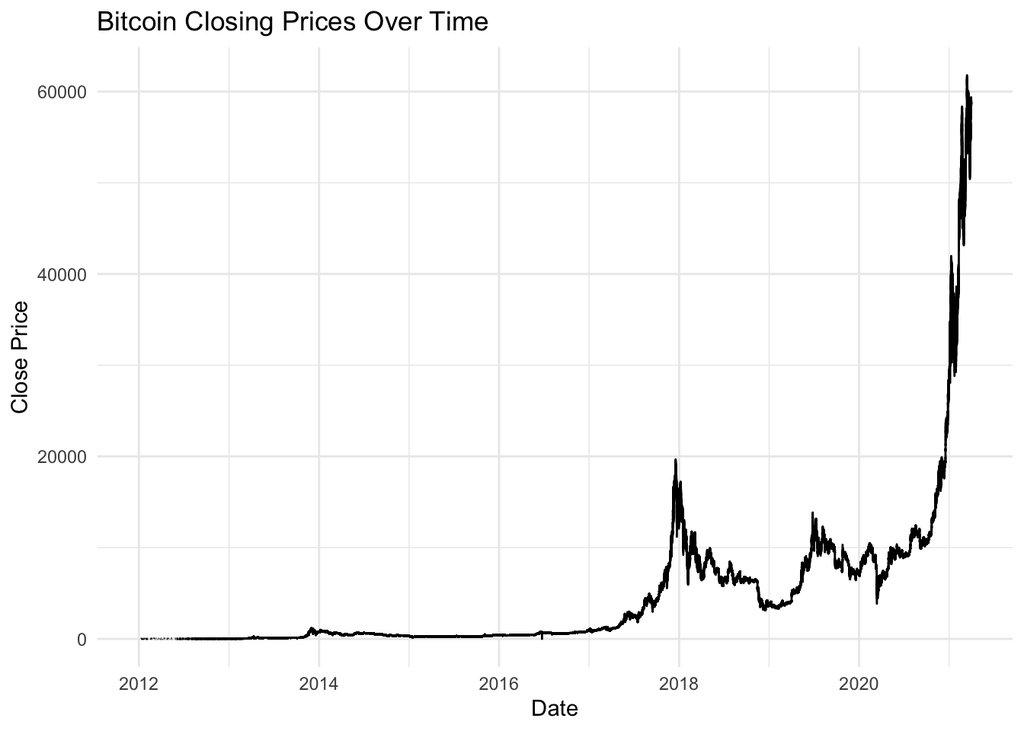

```r
# Plotting the closing prices with better visualization
ggplot(data, aes(x=Timestamp, y=Close)) +
  geom_line() +
  labs(x="Date", y="Close Price", title="Bitcoin Closing Prices Over Time") +
  theme_minimal()
```

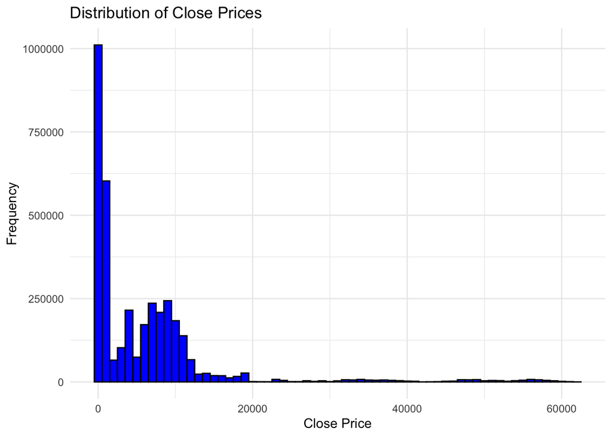

```r
# Histogram of Close prices to understand the distribution
ggplot(data, aes(Close)) +
  geom_histogram(binwidth = 1000, fill = "blue", color = "black") +
  labs(x = "Close Price", y = "Frequency", title = "Distribution of Close Prices") +
  theme_minimal()
```

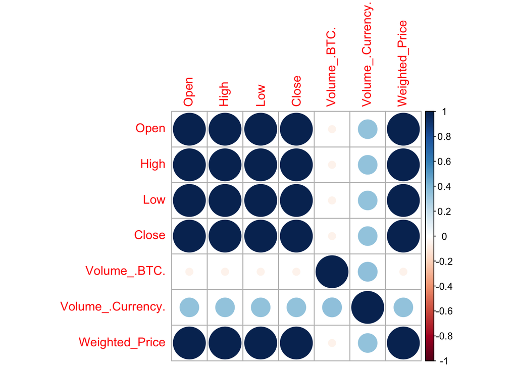

```r
# Correlation plot
correlation_matrix <- cor(data[complete.cases(data), -1], use = "everything")  # exclude timestamp and handling NA values
corrplot(correlation_matrix, method = "circle")
```

```r
## Checking Stationarity before modeling after splitting into train and test
```

# 5. Data Processing (Anomaly Detection, Cleansing and Imputations) and Transformations

```r
# Handling missing values using spline interpolation
data$Close <- na.spline(data$Close, na.rm = FALSE)
```

# 6. Feature Engineering

```r
# Engineering a rolling standard deviation feature
window_size <- 50
data$RollingStd <- rollapplyr(data$Close, width = window_size, FUN = sd, fill = NA)

# Calculate technical indicators
data$SMA20 <- SMA(data$Close, n = 20)
data$RSI14 <- RSI(data$Close, n = 14)
macd_result <- MACD(data$Close)
data$MACD <- macd_result[, "macd"]

data$CloseMA7 <- rollmean(data$Close, k = 7, fill = NA, align = "right")

# Let's see a glimpse of the data now
head(data)
```

```
##             Timestamp Open High  Low    Close Volume_.BTC. Volume_.Currency.
## 1 2011-12-31 07:52:00 4.39 4.39 4.39 4.390000    0.4555809                 2
## 2 2011-12-31 07:53:00  NaN  NaN  NaN 4.435663          NaN               NaN
## 3 2011-12-31 07:54:00  NaN  NaN  NaN 4.480960          NaN               NaN
## 4 2011-12-31 07:55:00  NaN  NaN  NaN 4.525891          NaN               NaN
## 5 2011-12-31 07:56:00  NaN  NaN  NaN 4.570458          NaN               NaN
## 6 2011-12-31 07:57:00  NaN  NaN  NaN 4.614662          NaN               NaN
##   Weighted_Price RollingStd SMA20 RSI14 MACD CloseMA7
## 1           4.39         NA    NA    NA   NA       NA
## 2            NaN         NA    NA    NA   NA       NA
## 3            NaN         NA    NA    NA   NA       NA
## 4            NaN         NA    NA    NA   NA       NA
## 5            NaN         NA    NA    NA   NA       NA
## 6            NaN         NA    NA    NA   NA       NA
```

# 7. Proposed Approaches (Model) with Justification and Trade-Offs, if Any

```r
# Calculate the index that splits the data into 80% training and 20% testing
split_index <- round(nrow(data) * 0.8)

# Create the training and testing sets
train <- data[1:(nrow(data) - 12), 'Close']
test <- data[(nrow(data) - 11):nrow(data), 'Close']

# Sample a subset of the data for the ADF test
sample_size <- 1000  # Adjust the sample size as per your computational limitations
sample_data <- sample(train, size = sample_size)

# Check if train data is stationary using Augmented Dickey Fuller Test
adf_test <- adf.test(sample_data)
# Print the results
print(adf_test)
```

```
##
##  Augmented Dickey-Fuller Test
##
## data:  sample_data
## Dickey-Fuller = -9.7442, Lag order = 9, p-value = 0.01
## alternative hypothesis: stationary
```

```r
# If necessary, difference the data to make it stationary
if (adf_test$p.value > 0.05) {
  train <- diff(train)
  test <- diff(test)
}
```

## Model 1: ARFIMA

```r
# Fit an ARFIMA model using the optimal d value
arfima_fit <- arfima(ts(train, frequency = 12))

# Make predictions on the test data
arfima_pred <- forecast(arfima_fit, h=12)
```

## Model 2: ARIMA

```r
# Automatically select the best ARIMA model for the training data
arima_fit <- auto.arima(ts(train))

# Make predictions on the test data using the best ARIMA model
arima_pred <- forecast(arima_fit, h = 12)
```

## Model 3: Exponential Smoothing

```r
# Fit an exponential smoothing state space model
ets_fit <- ets(ts(train))

# Make predictions on the test data using the ETS model
ets_pred <- forecast(ets_fit, h = 12)
```

## Model 4: SARIMA

```r
# Automatically select the best SARIMA model for the training data
sarima_fit <- auto.arima(ts(train), seasonal = TRUE)

# Make predictions on the test data using the best SARIMA model
sarima_pred <- forecast(sarima_fit, h = 12)
```

# 8. Results (Accuracy) and Learnings from the Methodology

```r
# Calculate the accuracy of the ARFIMA model
arfima_accuracy <- accuracy(arfima_pred, test)
cat("\nARFIMA Accuracy:\n")
```

```
##
## ARFIMA Accuracy:
```

```r
print(arfima_accuracy)
```

```
##                      ME      RMSE       MAE         MPE       MAPE      MASE
## Training set   4.113395  31.06695  11.08684 -13.0474907 15.2362913  2.709543
## Test set     384.590360 409.29779 384.59036   0.6549576  0.6549576 93.991074
##                  ACF1
## Training set 0.866014
## Test set           NA
```

```r
# Calculate the accuracy of the ARIMA model
arima_accuracy <- accuracy(arima_pred, test)
cat("\nARIMA Accuracy:\n")
```

```
##
## ARIMA Accuracy:
```

```r
print(arima_accuracy)
```

```
##                         ME     RMSE      MAE          MPE       MAPE      MASE
## Training set  9.628549e-06 14.98385  4.51175 -0.008051219 0.10593282  1.102639
## Test set     -5.717282e+01 64.97350 57.17282 -0.097383734 0.09738373 13.972621
##                     ACF1
## Training set -0.02332246
## Test set              NA
```

```r
# Calculate the accuracy of the ETS model
ets_accuracy <- accuracy(ets_pred, test)
cat("\nETS Accuracy:\n")
```

```
##
## ETS Accuracy:
```

```r
print(ets_accuracy)
```

```
##                       ME     RMSE       MAE          MPE       MAPE      MASE
## Training set  0.01238158 13.84458  4.086174 -0.009202639 0.10807467 0.9986311
## Test set     30.67369627 46.79980 36.366993  0.052210820 0.06191903 8.8878274
##                      ACF1
## Training set 0.0005498411
## Test set               NA
```

```r
# Calculate the accuracy of the SARIMA model
sarima_accuracy <- accuracy(sarima_pred, test)
cat("\nSARIMA Accuracy:\n")
```

```
##
## SARIMA Accuracy:
```

```r
print(sarima_accuracy)
```

```
##                         ME     RMSE      MAE          MPE       MAPE      MASE
## Training set  9.628549e-06 14.98385  4.51175 -0.008051219 0.10593282  1.102639
## Test set     -5.717282e+01 64.97350 57.17282 -0.097383734 0.09738373 13.972621
##                     ACF1
## Training set -0.02332246
## Test set              NA
```

The ETS model has the lowest values for the RMSE, MAE, and MAPE accuracy measures on the test set. Therefore, based on these measures, the ETS model appears to be the best performing model among the four models.

Here’s a ranking of the models based on their RMSE values on the test set, from best to worst:

ETS (RMSE = 46.79980) SARIMA (RMSE = 64.97350) ARIMA (RMSE = 64.97350) ARFIMA (RMSE = 409.29779)

## Plots of the Predictions

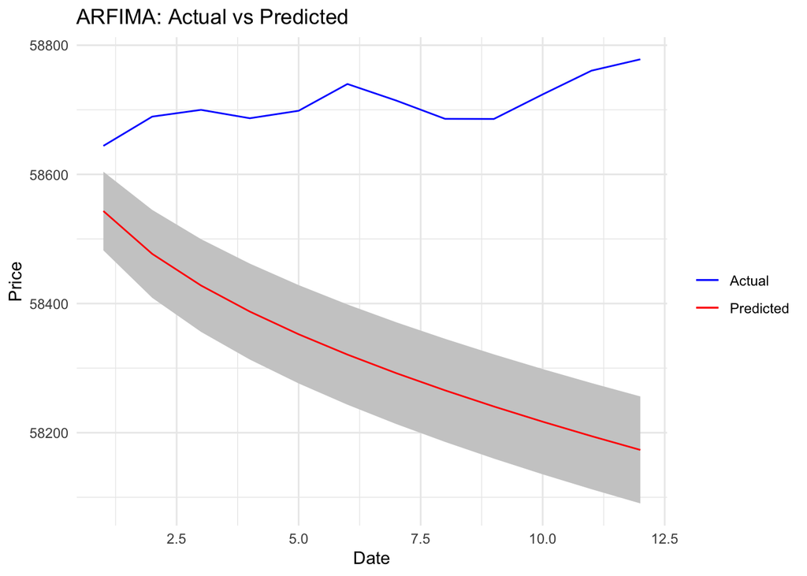

```r
# Generate plot for ARFIMA predictions
arfima_plot <- ggplot() +
  geom_ribbon(aes(x = index(test), ymin = arfima_pred$lower[,2], ymax = arfima_pred$upper[,2]), fill = "grey80") +
  geom_line(aes(x = index(test), y = test, colour = "Actual")) +
  geom_line(aes(x = index(test), y = arfima_pred$mean, colour = "Predicted")) +
  labs(x = "Date", y = "Price", title = "ARFIMA: Actual vs Predicted") +
  scale_color_manual(name = "", values = c("Actual" = "blue", "Predicted" = "red")) +
  theme_minimal()

# Generate plot for ARIMA predictions
arima_plot <- ggplot() +
  geom_ribbon(aes(x = index(test), ymin = arima_pred$lower[,2], ymax = arima_pred$upper[,2]), fill = "grey80") +
  geom_line(aes(x = index(test), y = test, colour = "Actual")) +
  geom_line(aes(x = index(test), y = arima_pred$mean, colour = "Predicted")) +
  labs(x = "Date", y = "Price", title = "ARIMA: Actual vs Predicted") +
  scale_color_manual(name = "", values = c("Actual" = "blue", "Predicted" = "red")) +
  theme_minimal()

# Generate plot for ETS predictions
ets_plot <- ggplot() +
  geom_ribbon(aes(x = index(test), ymin = ets_pred$lower[,2], ymax = ets_pred$upper[,2]), fill = "grey80") +
  geom_line(aes(x = index(test), y = test, colour = "Actual")) +
  geom_line(aes(x = index(test), y = ets_pred$mean, colour = "Predicted")) +
  labs(x = "Date", y = "Price", title = "ETS: Actual vs Predicted") +
  scale_color_manual(name = "", values = c("Actual" = "blue", "Predicted" = "red")) +
  theme_minimal()

# Generate plot for SARIMA predictions
sarima_plot <- ggplot() +
  geom_ribbon(aes(x = index(test), ymin = sarima_pred$lower[,2], ymax = sarima_pred$upper[,2]), fill = "grey80") +
  geom_line(aes(x = index(test), y = test, colour = "Actual")) +
  geom_line(aes(x = index(test), y = sarima_pred$mean, colour = "Predicted")) +
  labs(x = "Date", y = "Price", title = "SARIMA: Actual vs Predicted") +
  scale_color_manual(name = "", values = c("Actual" = "blue", "Predicted" = "red")) +
  theme_minimal()


# Display the plots
arfima_plot
```

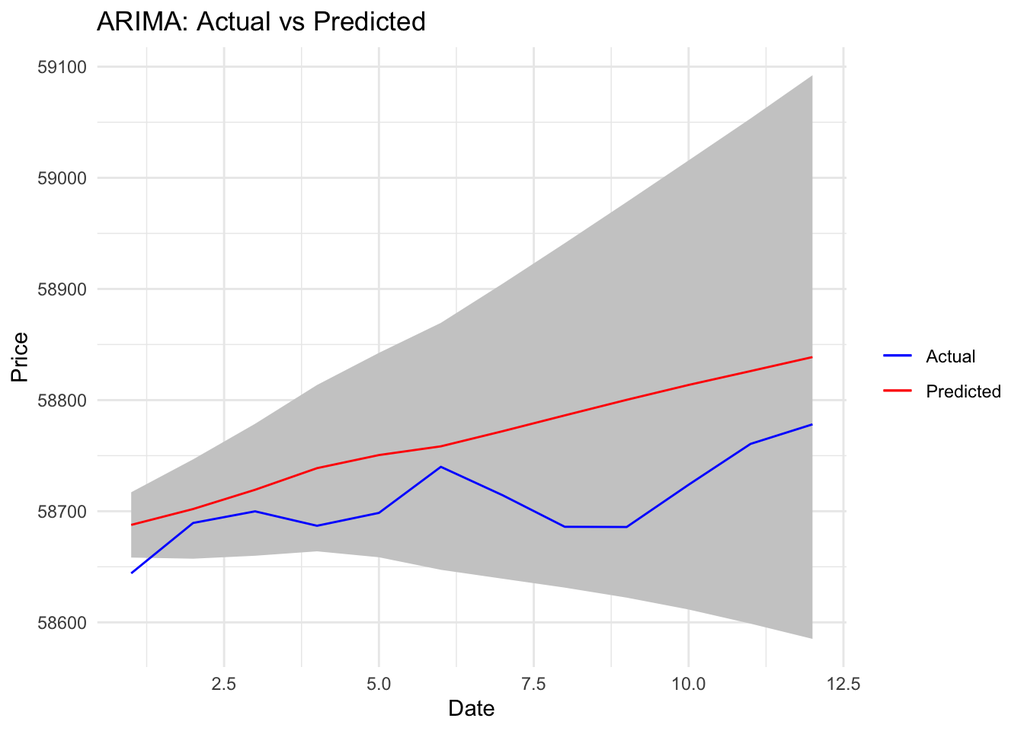

```r
arima_plot
```

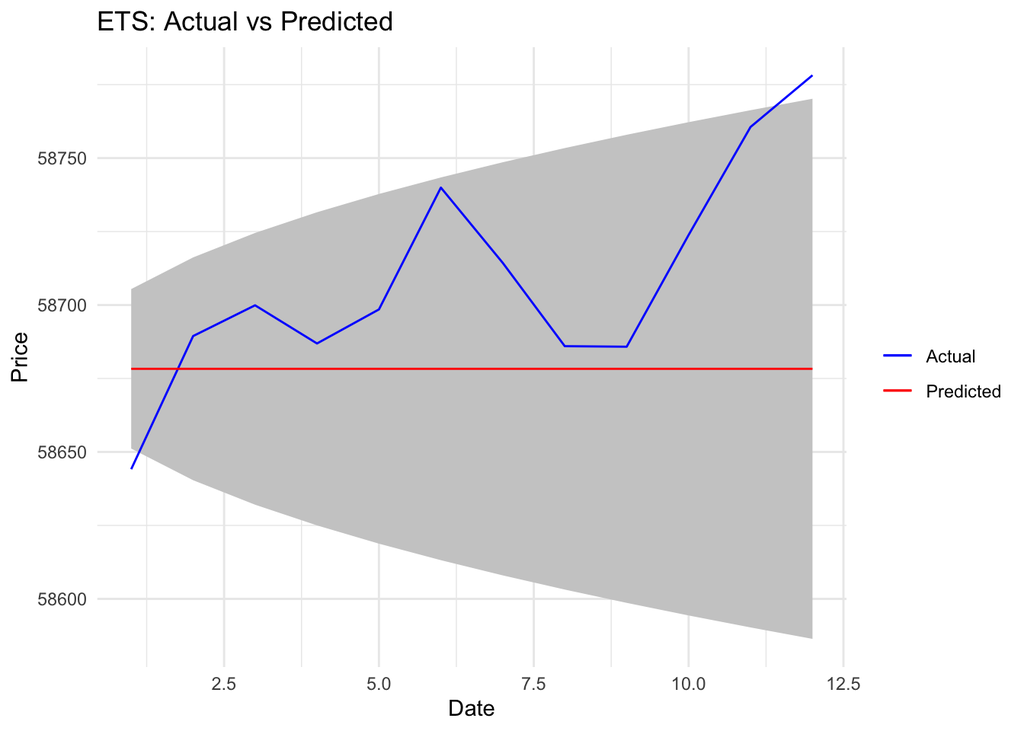

```r
ets_plot
```

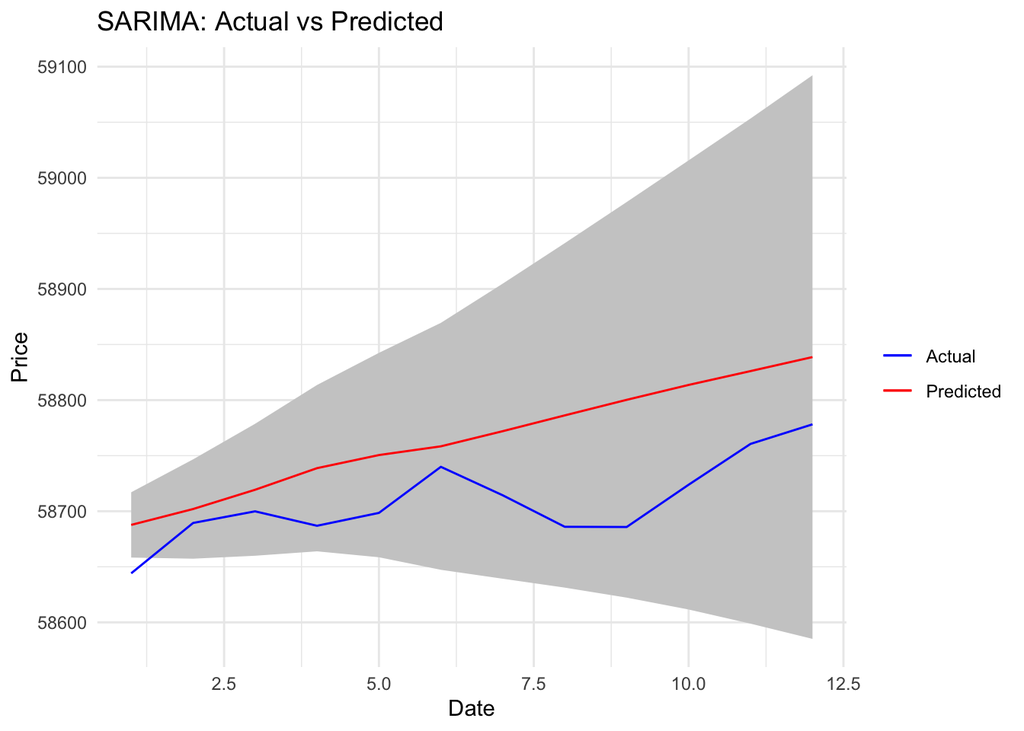

```r
sarima_plot
```

# 9. Future Work

Experiment with additional models and techniques: In addition to the ARFIMA, ARIMA, ETS, and SARIMA models used in this project, it would be interesting to experiment with other forecasting models and techniques to see if they can improve the accuracy of the predictions. For example, exploring the use of machine learning algorithms such as neural networks or support vector regression to forecast Bitcoin prices could be a promising avenue for future research.

Incorporate additional data sources: Incorporating additional data sources into the analysis, such as news articles or social media sentiment, could provide valuable context and help better understand the factors that influence Bitcoin prices.

Conduct a more detailed analysis of model performance: Conducting a more detailed analysis of the performance of each model, including an examination of the residuals and an evaluation of the model’s assumptions, could help better understand the strengths and weaknesses of each model and identify areas for improvement.

Explore ensemble methods: Exploring the use of ensemble methods to combine the forecasts from multiple models could potentially improve the accuracy of the predictions by leveraging the strengths of each individual model.